# Research Methods in Political Science I

Assignment 3

Yoshitaka Komiya

October 28, 2015

# Question 1

- Create an R function to calculate factorials.
1. Name an R function to calculate factorials “cal_fact” and regard n as argument.
2. I devide into three condition.
   1. Display an error message (if (n < 0)).
   2. Return 1 (if (n == 0)).
   3. calculate factorial (if (n > 0)).
3. Return y.

```r
cal_fact <- function(n) {
  #Arugument:n
  if(n < 0) { # The case which the argument is less than zero
    #Display an error message
    y <- c("The argument must be larger than 0.")
    return(y) #Return y
  }
  if(n == 0)  { #If x equals to zero
    y <- 1
    return(y) #Return y
  }
  if(n > 0)  { # If the argument is larger than zero
    x <- seq(1,n,by = 1) #integers from 1 to n
    y <- prod(1:n) #Multiply from 1 to n
  return(y) #Return y
  }
}
```

Compare “cal_fact” with “factorial” in R.

```r
#Comparison between the user defiend function, cal_fact, and factorial in R
cal_fact(4)
```

```
## [1] 24
```

```r
factorial(4)
```

```
## [1] 24
```

Get the same answer.

# Question 2

- Using your own factorial function, create an R function to calculate the number of possible combinations that can be obtained by taking a subset of elements.
1. Name an R function to calculate the number of possible combinations “cal_com” and regard n & k as arguments.
2. Devide into 2 condition.
   1. return 0 (if (n < k)).
   2. calculate combination (if (n >= K)).
3. Return z.

```r
cal_com <- function(n,k){
  # Arguments: n, k
  if(n < k) { # If k is larger than n
    z <- 0
    return(z) #Return z
  }
  if(n >= k) { #If n is larger than k
    s <- cal_fact(n)
    r <- (cal_fact(k) * cal_fact(n - k))
    z <- s / r
  return(z) # Return z
  }
}
```

Compare “cal_com” with “choose” in R.

```r
#Comparison between the user defiend function, cal_com, and choose in R
  cal_com(5,3)
```

```
## [1] 10
```

```r
  choose(5,3)
```

```
## [1] 10
```

Get the same answer.

# Question 3

- Using your own combination function, create an R function to calculate the probability mass of binomial distributions.
1. Name an R function to calculate the probability mass of binominal distributions “cal_bin”.
2. Calculate the binominary probability by using “cal_com”.
3. Return d.

```r
cal_bin <- function(x,n,p) {
   # Arguments: x - number of success (integer)
   #            n - number of bernoulli trials (integer)
   #            p - probability of success (integer)
  a <- cal_com(n,x)
  b <- p ^ x
  c <- (1 - p) ^ (n - x)
  d <- a * b * c # Calculate the binomial probability
  return(d) #Return d
}
```

Compare “cal_bin” with “dbinom” in R.

```r
  #Comparison between the user defiend function, cal_bin, and dbinom in R
cal_bin(1,10,0.5)
```

```
## [1] 0.009765625
```

```r
dbinom(1,10,0.5)
```

```
## [1] 0.009765625
```

Get the same answer.

# Question 4

- Using your own binomial PMF, display graphically the PMF of binomial distributions for n = 2, 5, 10, and 50. You can choose p as you like, but you have to use at least two different values for p.

Display the plot of “p=0.2”.

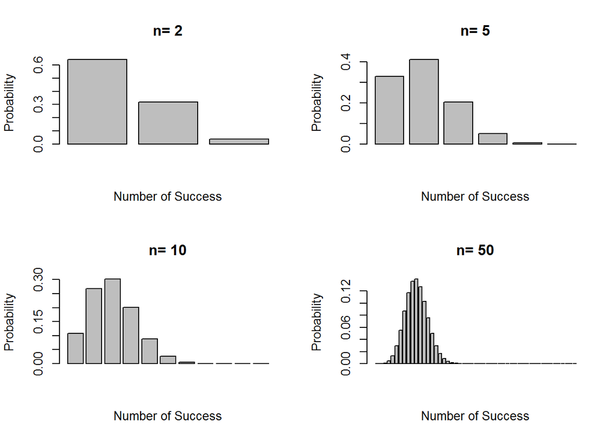

```r
op <- par(mfrow=c(2,2)) #Decide the place of graph
  for (i in c(2,5,10,50)) { # loop for the simulation, i = 2, 5, 10, 50
    chk <- rep(NA, length = i)
  for(j in 0:i){ # loop for the simulation, i = 0, 1, ..., i
    chk[j + 1] <- cal_bin(j, i, 0.2)
  }
  barplot(chk, xlab = "Number of Success", ylab = "Probability", col = "gray", main = paste("n=",i))
  # Display the plot of "p = 0.2"   with dividing by "n"
}
```

Display the plot of “p=0.4”.

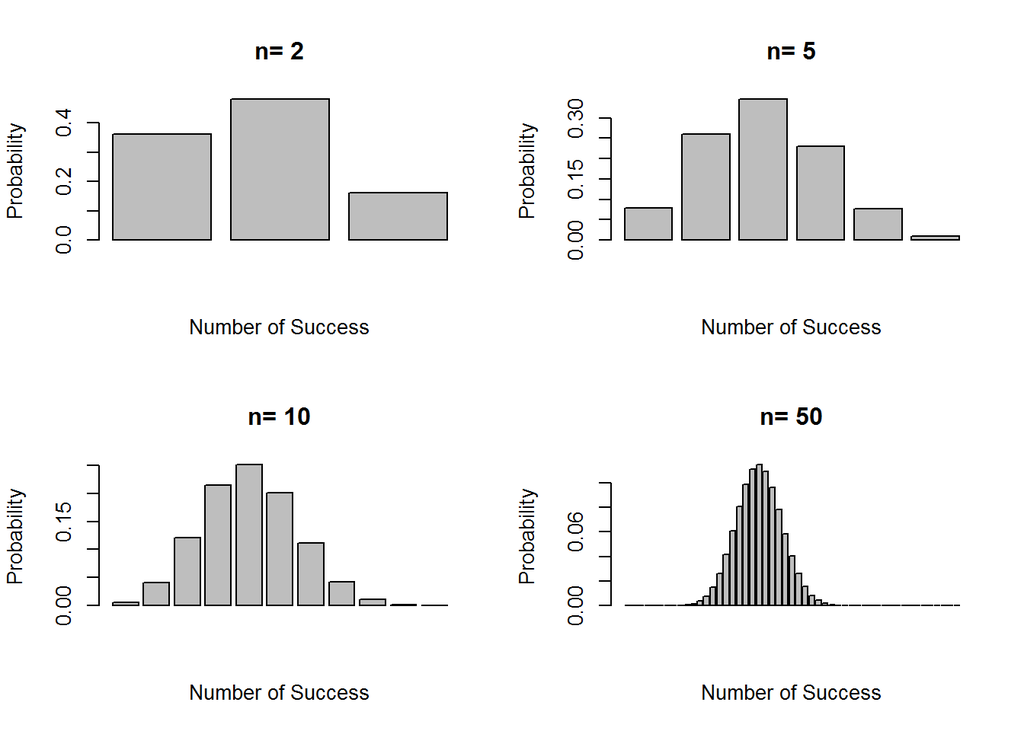

```r
op <- par(mfrow=c(2,2)) #Decide the place of graph
  for (i in c(2,5,10,50)) { # loop for the simulation, i = 2, 5, 10, 50
    chk <- rep(NA, length = i)
  for(j in 0:i){ # loop for the simulation, i = 0, 1, ..., i
    chk[j + 1] <- cal_bin(j, i, 0.4)
  }
  barplot(chk, xlab = "Number of Success", ylab = "Probability", col = "gray", main = paste("n=",i))
  # Display the plot of "p = 0.2" with dividing by "n"
}
```